# Self-Driving Car Engineer Nanodegree

### Model Architecture

```python
### Define your architecture here.
### Feel free to use as many code cells as needed.
from tensorflow.contrib.layers import flatten
EPOCHS=25
BATCH_SIZE=150
def Model_Arch(x):
    # Arguments used for tf.truncated_normal, randomly defines variables for the weights and biases for each layer
    mu = 0
    sigma = 0.1
    filter_1 = tf.Variable(tf.truncated_normal(shape = (5,5,1,6),mean = mu,stddev = sigma))
    bias_1 = tf.Variable(tf.zeros(6))


    # TODO: Layer 1: Convolutional. Input = 32x32x1. Output = 28x28x6.
    #conv2d takes input,filter,strides,padding
    conv1 = tf.nn.conv2d(x,filter_1,strides=[1,1,1,1],padding = 'VALID')
    #adding bias
    conv1 = conv1 + bias_1


    # TODO: Activation.
    conv1 = tf.nn.relu(conv1)
    # TODO: Pooling. Input = 28x28x6. Output = 14x14x6.

    #maxpool takes input,internalwindowsize,strides,padding

    conv1 = tf.nn.avg_pool(conv1,ksize = [1,2,2,1],strides = [1,2,2,1],padding = 'VALID')

    first_layer_output = conv1
    #first_layer_output_size  14*14*6
    # TODO: Layer 2: Convolutional. Output = 10x10x16.
    #shape for truncatednormal in filter is (,,inputdepth,outputdepth)

    filter_2 = tf.Variable(tf.truncated_normal(shape = (5,5,6,16),mean = mu,stddev = sigma))

    bias_2 = tf.Variable(tf.zeros(16))
    conv2 = tf.nn.conv2d(first_layer_output,filter_2,strides=[1,1,1,1],padding = 'VALID')
    conv2 = conv2+bias_2




    # TODO: Activation.

    conv2 = tf.nn.relu(conv2)

    # TODO: Pooling. Input = 10x10x16. Output = 5x5x16.

    conv2 = tf.nn.avg_pool(conv2,ksize = [1,2,2,1],strides = [1,2,2,1],padding = 'VALID')

    # TODO: Flatten. Input = 5x5x16. Output = 400.

    second_layer_output = conv2

    flatted_input = flatten(second_layer_output)

    # TODO: Layer 3: Fully Connected. Input = 400. Output = 120.
    weight_1  = tf.Variable(tf.truncated_normal(shape = (400,200),mean = mu,stddev = sigma))
    bias_3 = tf.Variable(tf.zeros(200))

    output = tf.add(tf.matmul(flatted_input,weight_1),bias_3)
    # TODO: Activation.
    output = tf.nn.relu(output)
    output = tf.nn.dropout(output, prob)
    # TODO: Layer 4: Fully Connected. Input = 120. Output = 84.
    weight_2  = tf.Variable(tf.truncated_normal(shape = (200,100),mean = mu,stddev = sigma))
    bias_4  = tf.Variable(tf.zeros(100))
    output2 = tf.add(tf.matmul(output,weight_2),bias_4)
    output2 = tf.nn.relu(output2)
    output2 = tf.nn.dropout(output2, prob)

    # TODO: Activation.

    # TODO: Layer 5: Fully Connected. Input = 84. Output = 10.
    weight_3 = tf.Variable(tf.truncated_normal(shape=(100,43),mean = mu,stddev = sigma))
    bias_5 = tf.Variable(tf.zeros(43))
    output3 = tf.add(tf.matmul(output2,weight_3),bias_5)
    logits = output3
    return logits
```

### Train, Validate and Test the Model

A validation set can be used to assess how well the model is performing. A low accuracy on the training and validation sets imply underfitting. A high accuracy on the training set but low accuracy on the validation set implies overfitting.

```python
#Place Holders:-
x = tf.placeholder(tf.float32, (None, 32, 32, 1))
y = tf.placeholder(tf.int32, (None))
prob = tf.placeholder(tf.float32)
one_hot_y = tf.one_hot(y, 43)
```

```python
###Training Pipeline the dataset####
rate = 0.005

logits = Model_Arch(x)
cross_entropy = tf.nn.softmax_cross_entropy_with_logits(labels=one_hot_y, logits=logits)
loss_operation = tf.reduce_mean(cross_entropy)
optimizer = tf.train.AdamOptimizer(learning_rate = rate)
training_operation = optimizer.minimize(loss_operation)
```

```python
###Evalute the model####

correct_prediction = tf.equal(tf.argmax(logits, 1), tf.argmax(one_hot_y, 1))
accuracy_operation = tf.reduce_mean(tf.cast(correct_prediction, tf.float32))
saver = tf.train.Saver()

def evaluate(X_data, y_data):
    num_examples = len(X_data)
    total_accuracy = 0
    sess = tf.get_default_session()
    for offset in range(0, num_examples, BATCH_SIZE):
        batch_x, batch_y = X_data[offset:offset+BATCH_SIZE], y_data[offset:offset+BATCH_SIZE]
        accuracy = sess.run(accuracy_operation, feed_dict={x: batch_x, y: batch_y,prob:1.0})
        total_accuracy += (accuracy * len(batch_x))
    return total_accuracy / num_examples
```

```python
###Training out Model#####
with tf.Session() as sess:
    sess.run(tf.global_variables_initializer())
    num_examples = len(X_train)

    print("Training...")
    print()
    for i in range(EPOCHS):
        X_train, y_train = shuffle(X_train, y_train)
        for offset in range(0, num_examples, BATCH_SIZE):
            end = offset + BATCH_SIZE
            batch_x, batch_y = X_train[offset:end], y_train[offset:end]
            sess.run(training_operation, feed_dict={x: batch_x, y: batch_y,prob:0.7})

        validation_accuracy = evaluate(X_valid1, y_valid1)
        print("EPOCH {} ...".format(i+1))
        print("Validation Accuracy = {:.3f}".format(validation_accuracy))
        print()

    saver.save(sess, 'TrafficSign.ckpt')
    print("Model saved")
```

```
Training...

EPOCH 1 ...
Validation Accuracy = 0.786

EPOCH 2 ...
Validation Accuracy = 0.874

EPOCH 3 ...
Validation Accuracy = 0.915

EPOCH 4 ...
Validation Accuracy = 0.939

EPOCH 5 ...
Validation Accuracy = 0.959

EPOCH 6 ...
Validation Accuracy = 0.960

EPOCH 7 ...
Validation Accuracy = 0.966

EPOCH 8 ...
Validation Accuracy = 0.972

EPOCH 9 ...
Validation Accuracy = 0.975

EPOCH 10 ...
Validation Accuracy = 0.969

EPOCH 11 ...
Validation Accuracy = 0.978

EPOCH 12 ...
Validation Accuracy = 0.976

EPOCH 13 ...
Validation Accuracy = 0.979
```

[output cut: 23 more lines]

```
Validation Accuracy = 0.980

EPOCH 22 ...
Validation Accuracy = 0.987

EPOCH 23 ...
Validation Accuracy = 0.986

EPOCH 24 ...
Validation Accuracy = 0.986

EPOCH 25 ...
Validation Accuracy = 0.982

Model saved
```

## Step 3: Test a Model on New Images

To give yourself more insight into how your model is working, download at least five pictures of German traffic signs from the web and use your model to predict the traffic sign type.

You may find `signnames.csv` useful as it contains mappings from the class id (integer) to the actual sign name.

```python
with tf.Session() as sess:
    sess.run(tf.global_variables_initializer())
    saver.restore(sess, './TrafficSign.ckpt')

    test_accuracy = sess.run(accuracy_operation, feed_dict={x: X_test, y: y_test,prob : 1.0})

print('Test Accuracy: {}'.format(test_accuracy))
```

```
Test Accuracy: 0.9244661331176758
```

```python
###validating my model##############
from numpy import newaxis
X_valid = preprocess(X_valid,"valid")
X_valid = X_valid[...,newaxis]
saver = tf.train.Saver()
with tf.Session() as sess:
    sess = tf.get_default_session()
    saver.restore(sess, './TrafficSign.ckpt')

    test_accuracy = sess.run(accuracy_operation, feed_dict={x: X_valid, y: y_valid,prob : 1.0})

print('Validation Accuracy: {}'.format(test_accuracy))
```

```
Validation Accuracy: 0.9498868584632874
```

### Predict the Sign Type for Each Image

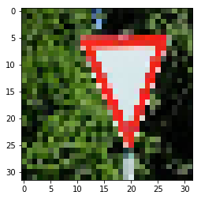

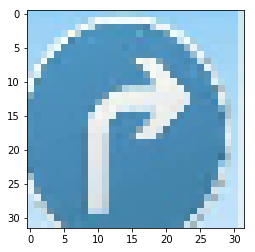

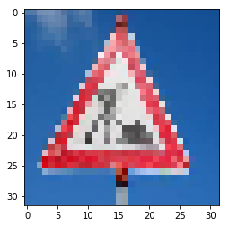

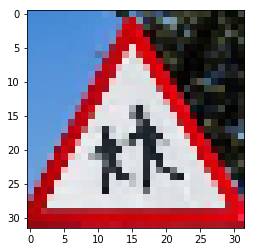

[figure not shown]

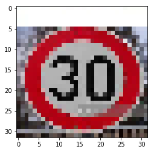

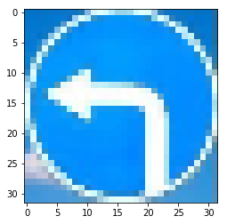

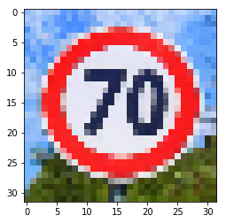

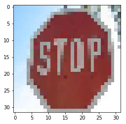

```python
### Run the predictions here and use the model to output the prediction for each image.
### Make sure to pre-process the images with the same pre-processing pipeline used earlier.
### Feel free to use as many code cells as needed.

import os
import matplotlib.image as mpimg
test_images = os.listdir("TestImages/")

# Show the images, add to a list to process for classifying
test_image_list = []
for i in range(1,len(test_images)+1):
    temp_image = './TestImages/Image' + str(i)+'.jpg'
    temp_image = mpimg.imread(temp_image)
    temp_image = cv2.resize(temp_image,(32,32))
    test_image_list.append(temp_image)
    plt.imshow(temp_image)
    plt.show()
```

### Analyze Performance

```python
###Preprocessing the testing images###################
test_image_list=np.asarray(test_image_list)
print(test_image_list.shape)
test_image_list=preprocess(test_image_list)
test_image_list =test_image_list[...,newaxis]
print(test_image_list.shape)
```

```
(9, 32, 32, 3)
(9, 32, 32, 1)
```

```python
### Calculate the accuracy for these 5 new images.
### For example, if the model predicted 1 out of 5 signs correctly, it's 20% accurate on these new images.
with tf.Session() as sess:
#     saver.restore(sess, './TrafficSign.ckpt')
    new_saver = tf.train.import_meta_graph('TrafficSign.ckpt.meta')
    new_saver.restore(sess,tf.train.latest_checkpoint('.'))
    test_images_output = sess.run(tf.nn.softmax(logits), feed_dict={x: test_image_list,prob : 1.0})
print(test_images_output)
```

[output not shown]

[output cut: 44 more lines]

[output not shown]

### Output Top 5 Softmax Probabilities For Each Image Found on the Web

For each of the new images, print out the model's softmax probabilities to show the **certainty** of the model's predictions (limit the output to the top 5 probabilities for each image). [`tf.nn.top_k`](https://www.tensorflow.org/versions/r0.12/api_docs/python/nn.html#top_k) could prove helpful here.

The example below demonstrates how tf.nn.top_k can be used to find the top k predictions for each image.

`tf.nn.top_k` will return the values and indices (class ids) of the top k predictions. So if k=3, for each sign, it'll return the 3 largest probabilities (out of a possible 43) and the correspoding class ids.

Take this numpy array as an example. The values in the array represent predictions. The array contains softmax probabilities for five candidate images with six possible classes. `tf.nn.top_k` is used to choose the three classes with the highest probability:

```
# (5, 6) array
a = np.array([[ 0.24879643,  0.07032244,  0.12641572,  0.34763842,  0.07893497,
         0.12789202],
       [ 0.28086119,  0.27569815,  0.08594638,  0.0178669 ,  0.18063401,
         0.15899337],
       [ 0.26076848,  0.23664738,  0.08020603,  0.07001922,  0.1134371 ,
         0.23892179],
       [ 0.11943333,  0.29198961,  0.02605103,  0.26234032,  0.1351348 ,
         0.16505091],
       [ 0.09561176,  0.34396535,  0.0643941 ,  0.16240774,  0.24206137,
         0.09155967]])
```

Running it through `sess.run(tf.nn.top_k(tf.constant(a), k=3))` produces:

```
TopKV2(values=array([[ 0.34763842,  0.24879643,  0.12789202],
       [ 0.28086119,  0.27569815,  0.18063401],
       [ 0.26076848,  0.23892179,  0.23664738],
       [ 0.29198961,  0.26234032,  0.16505091],
       [ 0.34396535,  0.24206137,  0.16240774]]), indices=array([[3, 0, 5],
       [0, 1, 4],
       [0, 5, 1],
       [1, 3, 5],
       [1, 4, 3]], dtype=int32))
```

Looking just at the first row we get `[ 0.34763842, 0.24879643, 0.12789202]`, you can confirm these are the 3 largest probabilities in `a`. You'll also notice `[3, 0, 5]` are the corresponding indices.

```python
### Print out the top five softmax probabilities for the predictions on the German traffic sign images found on the web.
### Feel free to use as many code cells as needed.
with tf.Session() as sess:
    predicts = sess.run(tf.nn.top_k(test_images_output, k=5, sorted=True))
import csv
answers_list = []
probabilty_list = []
for i in range(0,len(predicts[0])):
    answers_list.append(predicts[1][i])
    probabilty_list.append(predicts[0][i])
print(answers_list)
import csv
complete_prediction = []
for i in answers_list:
    temp=[]
    for j in i:

        with open('signnames.csv') as csvfile:
             reader = csv.DictReader(csvfile)
             for row in reader:
                if row['ClassId'] == str(j):
                    temp.append(row['SignName'])
    complete_prediction.append(temp)
```

[output not shown]

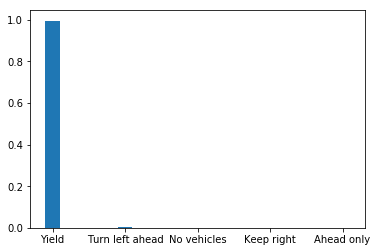

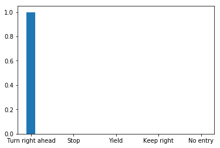

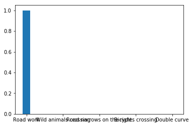

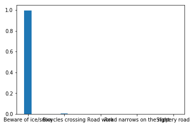

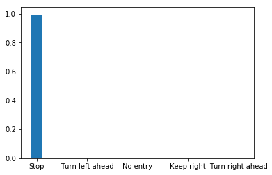

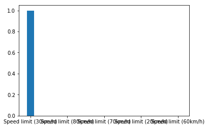

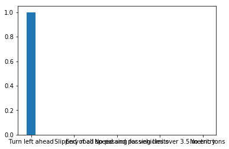

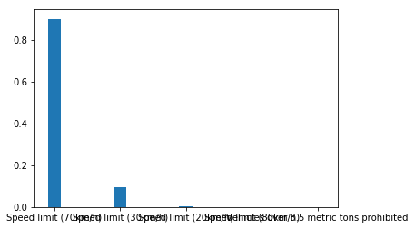

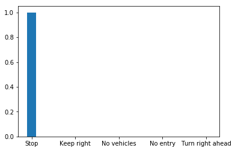

```python
for i in range(len(predicts[0])):
    temp = [i for i in range(1,len(complete_prediction[i])+1)]
    plt.bar(temp,probabilty_list[i],width = 0.2,orientation = "vertical")
    plt.xticks(temp,complete_prediction[i])
    plt.show()
```

```python
for i in range(len(predicts[0])):
    print("For Image ",str(i+1),"Probability's are")
    for j in range(len(complete_prediction[i])):
        print(str(complete_prediction[i][j]),"\t\t\t\t",str(probabilty_list[i][j]))
    print("\n\n")
```

```
For Image  1 Probability's are
Yield 				 0.995927
Turn left ahead 				 0.0040727
No vehicles 				 1.10008e-08
Keep right 				 5.16268e-09
Ahead only 				 2.13038e-09



For Image  2 Probability's are
Turn right ahead 				 0.99911
Stop 				 0.000889522
Yield 				 1.12821e-07
Keep right 				 8.23998e-08
No entry 				 3.56418e-08



For Image  3 Probability's are
Road work 				 0.999922
Wild animals crossing 				 6.98046e-05
Road narrows on the right 				 7.54203e-06
Bicycles crossing 				 3.58383e-07
Double curve 				 1.17357e-07



For Image  4 Probability's are
Beware of ice/snow 				 0.996524
Bicycles crossing 				 0.00339599
Road work 				 3.2852e-05
Road narrows on the right 				 2.63804e-05
Slippery road 				 1.73779e-05



For Image  5 Probability's are
Stop 				 0.994628
Turn left ahead 				 0.00512475
No entry 				 0.000216603
```

[output cut: 23 more lines]

```
For Image  8 Probability's are
Speed limit (70km/h) 				 0.899173
Speed limit (30km/h) 				 0.0967646
Speed limit (20km/h) 				 0.00406284
Speed limit (80km/h) 				 9.65189e-08
Vehicles over 3.5 metric tons prohibited 				 4.00468e-08



For Image  9 Probability's are
Stop 				 0.999997
Keep right 				 1.62969e-06
No vehicles 				 1.27416e-06
No entry 				 1.07422e-07
Turn right ahead 				 6.76303e-08
```